# Our Twitter Happy President

Rachel Castellino, Eric Tran, Miles Loef

1/31/2020

Do you ever think about just how much our 45th President of the United States tweets? We all hear about his Twitter activity in the news, but there has got to be a minefield of tweets that may not have been seen by the wider public before his election period. Have you ever wondered if Trump’s tweets have gotten more popular over the years? Maybe if he has a certain pattern to his tweets or loves repeating the same words? We felt we must look further into his tweeting history, to unlock some insights about the antics of this man. We used a dataset that has tracked President Trump’s tweets from 2009-2020 including the number of retweets, favorites, mentions, and other categories. Lucky for you, our team is here to tackle the behavior of our tweet-happy 45th President of the United States.

## Introduction

A quick thank you to GetOldTweets for providing the data for this dataset and to Austin Reese for compiling and condensing this dataset to Kaggle. The original data set includes details about the ID of each tweet, the tweet itself, the date and time stamp of when it was posted, the amount of favorites and retweets it got, and the people he tagged in the tweet itself. There are roughly 42,000 entries - yes you read that right, that’s how many tweets Trump has tweeted to date.

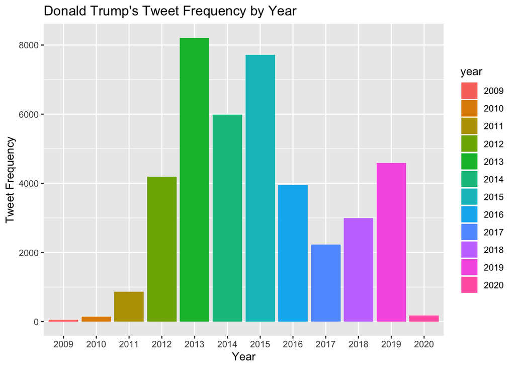

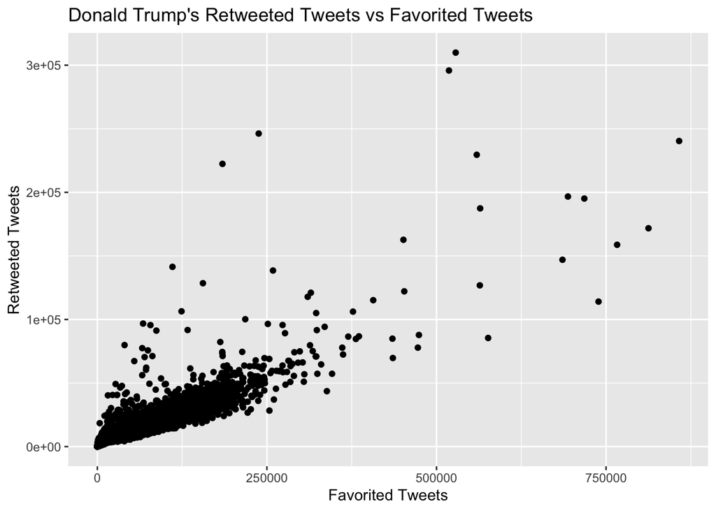

## Analysis

Donald Trump’s favorite words are exactly the ones you would most associate with him. Our team chose 5 words that we hear Donald Trump use a lot in the news, on social media, and just words we thought fit his personality type the most when tweeting. Of the 5 words ‘fuck’, ‘wall’, ‘fake news’, and ‘tremendous’, and ‘loser’, we found that Trump’s most used words were “fake news,” “wall,” and “tremendous.” Considering how many times he mentions building a tremendous wall on the border of Mexico or calls fake news on almost every relevant news topic, this isn’t a surprise.

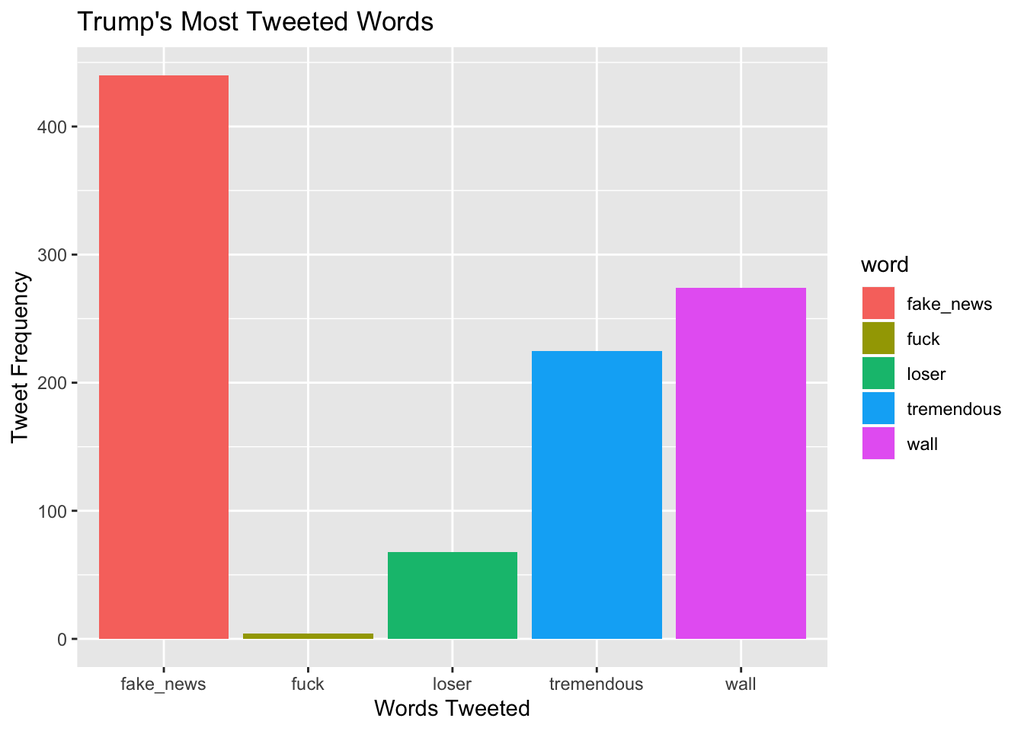

### Insight 2: Trump Tweets the Most Right Before Going to Bed

Sometimes it seems that Trump tweets all day every day. Like. all. the. time. So we decided to see if this was really true- how frequently during different parts of the day does Trump tweet? We found that Trump tweets the most when he is about to go to bed and during the middle of the night- quite a night owl he is. Even when you think he’s off golfing, he’s tweeting.

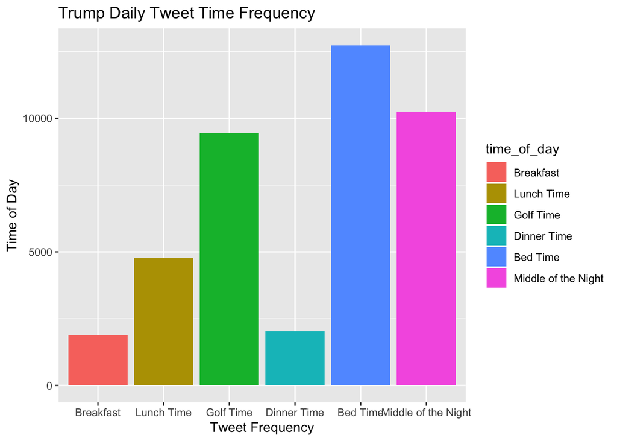

### Insight 3: Trump Is Most Popular During the Month of August

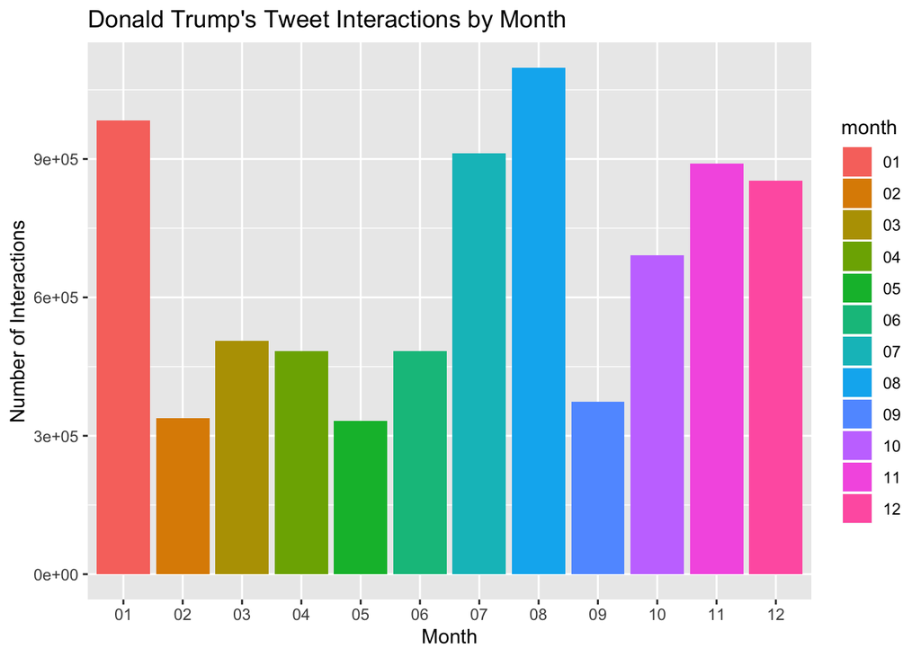